# 9. Anotación

## Tipos de anotación

### Anotación estructural

Identificar posiciones de elementos fundionales: genes, tránscritos, exones, CDSs, genes no codificantes, elementos reguladores…

### Anotación funcional

Atribuir funciones, asignar términos de ontología génica, símbolos génicos…

## Estructura génica

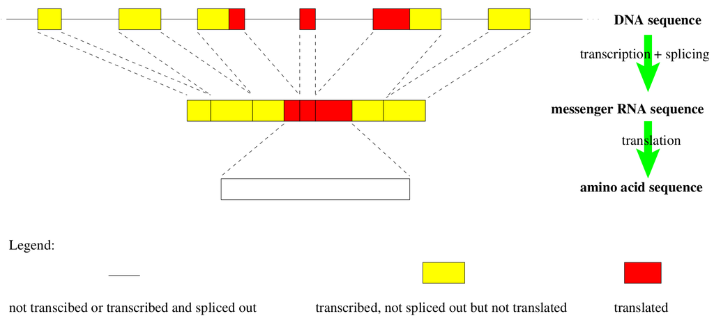

(M. Stanke 2003)

## Estrategias

1. Basadas en modelos génicos.
2. Ensamblaje de lecturas de RNA-seq.
3. Transferencia de anotaciones.

## Desafíos

1. Ensamblajes incompletos o fragmentados.
2. Tránscritos alternativos.
3. Pseudogenes y elementos transponibles.
4. Evidencias insuficientes (datos de expresión; divergencia).
5. Combinación de múltiples evidencias.

# Elementos repetitivos

## Clasificación

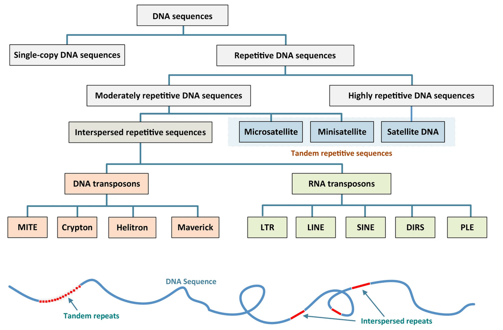

Liao et al. (2023)

## Estructura y distribución

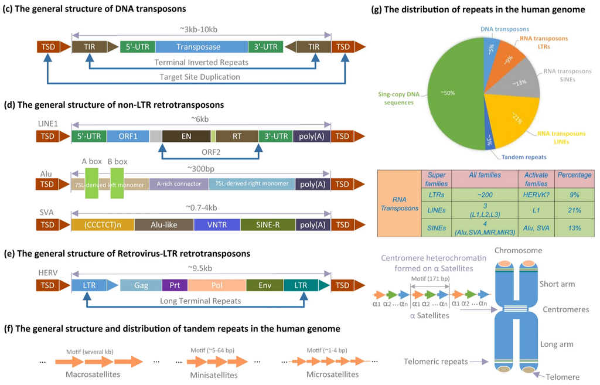

Liao et al. (2023)

## Procedimiento

1. RepeatModeler (Flynn et al. 2020): Identifica repeticiones propias del ensamblaje y genera una colección de secuencias consenso de cada familia.
2. [RepeatMasker](https://www.repeatmasker.org/): Usa una base de datos de elementos repetitivos conocidos para identificar y *enmascarar* cada ejemplar en el ensamblaje.

# Modelos génicos

## *Hidden Markov Models* (HMM)

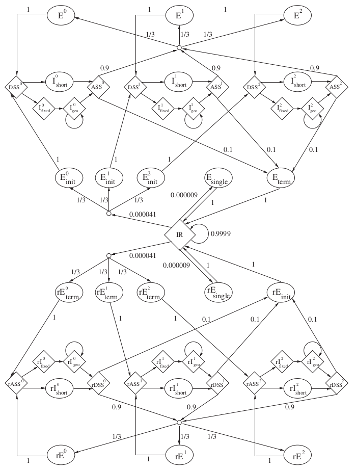

(Mario Stanke and Waack 2003)

- $IR$: región intergénica
- $E^n_{\mathrm{init}}$: primer exón codificante de varios.
- $E_{\mathrm{single}}$: único exón codificante.
- $E_{\mathrm{term}}$: exón terminal codificante.
- $E^n$: exón interno codificante.
- $I^n_{\mathrm{short}}$: intrón corto.
- $I^n_{\mathrm{fixed}}$: principio de intrón largo.
- $I^n_{\mathrm{geo}}$: resto del intrón largo.
- $DSS^n$: *donor splice site*.
- $ASS^n$: *acceptor splice site*.
- $n$: fase del último codón del exón (anterior).

## Entrenamiento

El HMM (matriz de transición, probabilidades de emisión) se ajusta a partir de genes conocidos o predichos con alta confianza a partir de:

- Proteínas de una especie próxima, o bien
- Alineamientos (con *splicing*) de lecturas de RNA-seq.

## Procedimiento

Se repiten los pasos siguientes hasta convergir:

- Predicción *ab initio* de genes nuevos.
- Refinamiento del modelo.

## Principales programas

- [AUGUSTUS](https://github.com/Gaius-Augustus/Augustus)(Mario Stanke and Waack 2003)
- [GeneMark](https://github.com/gatech-genemark/GeneMark-ETP)(Bruna, Lomsadze, and Borodovsky 2024)
- BRAKER
- STAR: para alinear lecturas RNA-seq al ensamblaje.

## Limitaciones

- No predicen UTRs ni ncRNAs. Sólo CDSs, normalmente.
- Necesitamos entrenar el modelo para cada especie.

# Ensamblaje de lecturas de RNA-seq

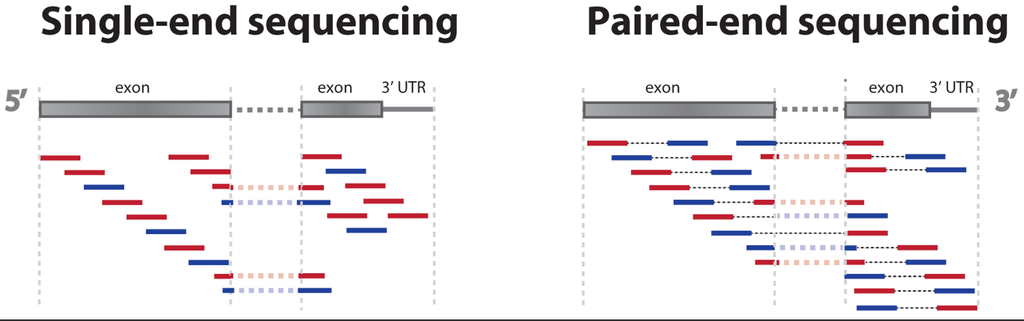

(Zhernakova 2013)

## Principales programas

### Alineamiento de RNA-seq

- [HISAT2](https://daehwankimlab.github.io/hisat2/) (Kim et al. 2019)
- STAR (Dobin et al. 2013)

### Identificación de tránscritos

- [StringTie](https://ccb.jhu.edu/software/stringtie/) (Shumate 2022). También cuantifica la expresión génica.
- [Scallop](https://github.com/Kingsford-Group/scallop) (Shao and Kingsford 2017)

# Transferencia de anotación

## Procedimiento

1. Alinear el ensamblaje a un genoma **próximo y bien anotado**.
2. Asignar las anotaciones originales a las zonas homólogas.

## Programas

- [Cactus](https://github.com/ComparativeGenomicsToolkit/cactus) (Armstrong et al. 2020) Para alinear genomas enteros.
- TOGA Para transferir la anotación.
- Liftoff También para transferir la anotación.

## Limitaciones

- Calidad de la anotación original.
- Distancia evolutiva entre el ensamblaje y el genoma anotado.

# Recapitulación

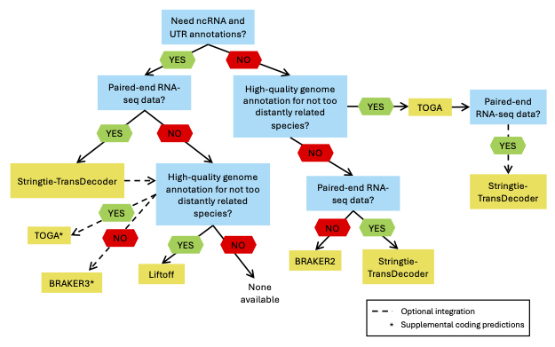

[Freedman, 2025](https://informatics.fas.harvard.edu/resources/tutorials/how-to-annotate-a-genome/)

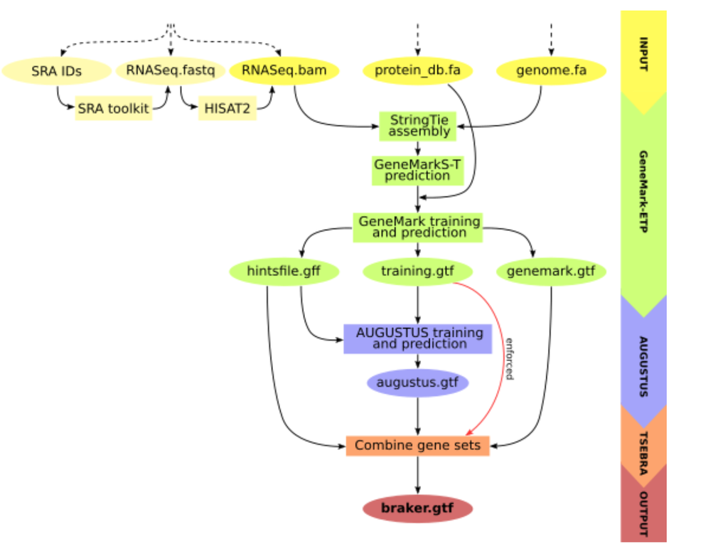

Arun Seetharam

# Resultados

## Archivos GFF2/GTF (`.gtf`)

```
contig1 source gene 330665 331775 15.0 + . gene_id “gene-id”; gene_name “gene-symbol”;
contig1 source transcript 330665 331775 15.0 + . transcript_id “rna-id”; gene_id “gene-id”; transcript_name “rna-symbol”;
contig1 source CDS 330665 330858 . + 2 transcript_id “rna-id”; gene_id “gene-id”;
contig1 source exon 330665 330858 . + . transcript_id “rna-id”; gene_id “gene-id”;
contig1 source CDS 331199 331775 . + 0 transcript_id “rna-id”; gene_id “gene-id”;
contig1 source exon 331199 331775 . + . transcript_id “rna-id”; gene_id “gene-id”;
contig1 source 3UTR 332802 333003 . + . transcript_id “rna-id”; gene_id “gene-id”;
```

## Archivos GFF3 (`.gff` o `.gff3`)

```
contig1 source  gene    330665  331775  15.0    +   .   ID=gene-id;Name=gene-symbol
contig1 source  mRNA    330665  331775  15.0    +   .   ID=rna-id;Parent=gene-id;Name=rna-symbol
contig1 source  CDS 330665  330858  .   +   2   ID=rna-id.CDS1;Parent=rna-id
contig1 source  exon    330665  330858  .   +   .   ID=rna-id.exon1;Parent=rna-id
contig1 source  CDS 331199  331775  .   +   0   ID=rna-id.CDS2;Parent=rna-id
contig1 source  exon    331199  331775  .   +   .   ID=rna-id.exon2;Parent=rna-id
contig1 source  three_prime_UTR 332802  333003  .   +   .   ID=rna-id.three_prime_UTR1;Parent=gene-id
```

## Visualización

[UCSC Genome Browser](https://genome.ucsc.edu/) [ENSEMBL](https://www.ensembl.org)

Existen opciones para instalar localmente.

## Evaluación del resultado

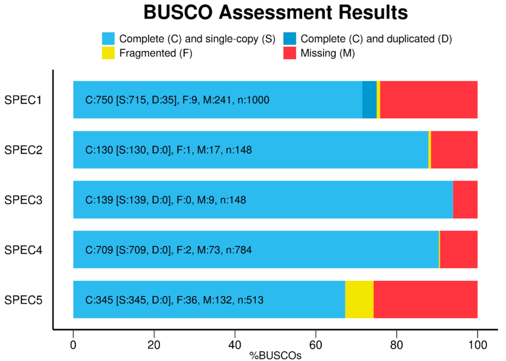

## Referencias y recursos

https://rcac-bioinformatics.github.io/genome-annotation/aio.html

https://informatics.fas.harvard.edu/resources/tutorials/how-to-annotate-a-genome/

Armstrong, J., G. Hickey, M. Diekhans, I. T. Fiddes, A. M. Novak, A. Deran, Q. Fang, et al. 2020. “Progressive Cactus Is a Multiple-Genome Aligner for the Thousand Genome Era.” *Nature* 587: 246–51. https://doi.org/10.1038/s41586-020-2871-y.

Bruna, T., A. Lomsadze, and M. Borodovsky. 2024. “GeneMark-ETP Significantly Improves the Accuracy of Automatic Annotation of Large Eukaryotic Genomes.” *Genome Research*, 757–68. https://doi.org/10.1101/gr.278373.123.

Dobin, Alexander, Carrie A. Davis, Felix Schlesinger, Jorg Drenkow, Chris Zaleski, Sonali Jha, Philippe Batut, Mark Chaisson, and Thomas R. Gingeras. 2013. “STAR: Ultrafast Universal RNA-Seq Aligner.” *Bioinformatics* 29 (1): 15–21. https://doi.org/10.1093/bioinformatics/bts635.

Flynn, Jullien M., Robert Hubley, Clément Goubert, Jeb Rosen, Andrew G. Clark, Cédric Feschotte, and Arian F. Smit. 2020. “RepeatModeler2 for Automated Genomic Discovery of Transposable Element Families.” *Proceedings of the National Academy of Sciences* 117 (17): 9451–57. https://doi.org/10.1073/pnas.1921046117.

Kim, D., J. M. Paggi, C. Park, C. Bennett, and S. L. Salzberg. 2019. “Graph-Based Genome Alignment and Genotyping with HISAT2 and HISAT-Genotype.” *Nature Biotechnology* 37: 907–15. https://doi.org/10.1038/s41587-019-0201-4.

Liao, X., W. Zhu, J. Zhou, H. Li, X. Xu, B. Zhang, and X. Gao. 2023. “Repetitive DNA Sequence Detection and Its Role in the Human Genome.” *Communications Biology* 6: 954. https://doi.org/10.1038/s42003-023-05322-y.

Shao, M., and C. Kingsford. 2017. “Accurate Assembly of Transcripts Through Phase-Preserving Graph Decomposition.” *Nature Biotechnology* 35: 1167–69. https://doi.org/10.1038/nbt.4020.

Shumate, Brandon AND Pertea, Alaina AND Wong. 2022. “Improved Transcriptome Assembly Using a Hybrid of Long and Short Reads with StringTie.” *PLOS Computational Biology* 18 (6): 1–18. https://doi.org/10.1371/journal.pcbi.1009730.

Stanke, M. 2003. “Gene Prediction with a Hidden Markov Model.” PhD thesis, Universität Göttingen.

Stanke, Mario, and Stephan Waack. 2003. “Gene Prediction with a Hidden Markov Model and a New Intron Submodel.” *Bioinformatics* 19 (suppl_2): ii215–25. https://doi.org/10.1093/bioinformatics/btg1080.

Zhernakova, Eleonora AND Westra, Daria V. AND de Klerk. 2013. “DeepSAGE Reveals Genetic Variants Associated with Alternative Polyadenylation and Expression of Coding and Non-Coding Transcripts.” *PLOS Genetics* 9 (6): 1–15. https://doi.org/10.1371/journal.pgen.1003594.